# Scaling and Clipping Images

Richard Cotton

2024-04-09

## Scaling Images

By default, images (such as JPEG, PNG, BMP, SVG) that are placed in panels are not scaled. This section demonstrates the four different scaling options available.

```r
library(multipanelfigure)
figure <- multi_panel_figure(
  width = c(1, 5),
  height = c(1, 1, 4),
  unit = "inches")
r_logo <- system.file("extdata/Rlogo.png", package = "multipanelfigure")
```

By default, the image is not rescaled, which means that only the central part of the image is displayed.

```
## Setting row to 1
```

```
## Setting column to 1
```

[figure not shown]

```r
(figure %<>% fill_panel(r_logo))
```

By setting `scaling = "stretch"`, all the image is displayed, fitting the panel exactly, but the height-to-width ratio had been altered, distorting the image.

```
## Setting row to 1
```

```
## Setting column to 2
```

[figure not shown]

```r
(figure %<>% fill_panel(r_logo, scaling = "stretch"))
```

Setting `scaling = "fit"` means that the image is shrunked or grown so that it just fits inside the panel without the height-to-width ratio being distorted.

```
## Setting row to 2
```

```
## Setting column to 1
```

[figure not shown]

```r
(figure %<>% fill_panel(r_logo, scaling = "fit"))
```

Setting `scaling = "shrink"`, works the same way as `scaling = "fit"` when the image is larger than the panel.

[figure not shown]

```r
(figure %<>% fill_panel(r_logo, scaling = "shrink", row = 3, column = 1))
```

If the image is smaller than the panel, `scaling = "shrink"` works like `scaling = "none"`.

[figure not shown]

```r
(figure %<>% fill_panel(r_logo, scaling = "shrink", row = 2:3, column = 2))
```

## Clipping Plots and Images

By default, plots and images are clipped so that they don’t overrun the panel that they were put in. (See, for example, Panel A in the previous plot.) To demonstrate the effect of clipping, let’s use a 3 by 3 multi-panel figure, and fill all but the centre panel.

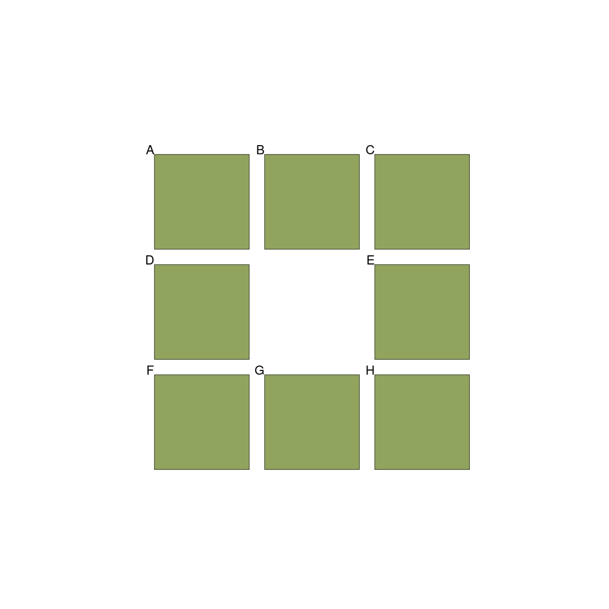

```r
library(grid)
figure2 <- multi_panel_figure(
  width = rep.int(1.25, 3),
  height = rep.int(1.25, 3),
  unit = "inches")
rhino <- system.file("extdata/rhino.jpg", package = "multipanelfigure")
for(position in list(c(1, 1), c(1, 2), c(1, 3), c(2, 1), c(2, 3), c(3, 1), c(3, 2), c(3, 3)))
{
  figure2 %<>%
    fill_panel(
      rectGrob(gp = gpar(fill = "#91A45E")),
      row = position[1],
      column = position[2])
}
figure2
```

When we try to display the rhino, only the central part of the image is shown, since there is no rescaling, and the panel isn’t big enough.

```
## Setting row to 2
```

```
## Setting column to 2
```

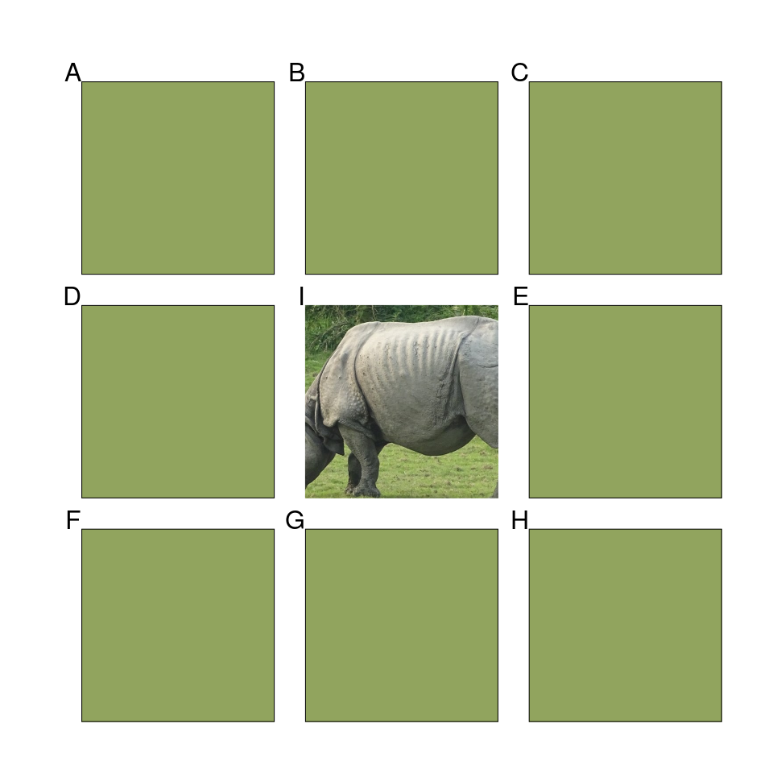

```r
(figure2 %>% fill_panel(rhino))
```

To turn off clipping, set `panel_clip = "off"`. This time the complete image of the rhino is displayed, overrunning the other panel regions.

```
## Setting row to 2
```

```
## Setting column to 2
```

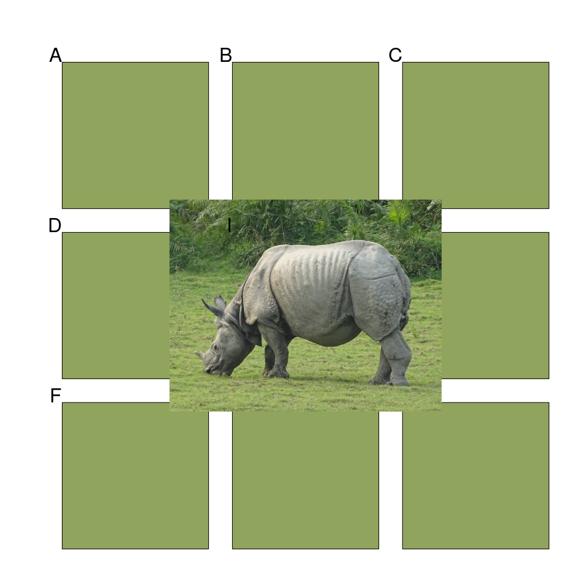

```r
(figure2 %>% fill_panel(rhino, panel_clip = "off"))
```